# BAYESIAN INFERENCE FOR NORMAL MEAN

15 Mar 2021 (*updated: 2021-03-15)*

## Admin & Startup

## Schedule review

Let’s review the schedule and place today’s learning in context.

## Action items this week

- Read Chapter 11, 12.
- Will get your grades up to date asap. Thank you for your patience. If you ever have questions just let me know.
- Problem Set 6, Ch. 9, 10 is due Friday, 19 Mar 2021.
- Midterm 2 (canvas quiz format) is due Friday, 19 Mar 2021.

## Any questions over problem set 6, Ch. 9,10?

- Ch.9 #1-3,C1
- Ch.10 #2, C1,C3-C6

## Today’s plan

- Prime by reading HW 7, ch. 11-13 exercise prompts.
- Discussion Ch. 11
- Summarize, Revisit HW or Q & A

*Please contribute questions and comments*

## II. Problem Set 7, Ch. 11-13

- Ch.11 #2,5, C5-C7,
- Ch.12 #4
- Ch.13 #1,2,16

## I. Bayesian Inference for Normal Mean (ch. 11)

## Recall standardization

centering at 0 and scaling to unit variance:  
\(Z = \frac{X - \mu}{\sigma}\).

## 11.1 Bayes’ Theorem for Normal Mean with a Discrete Prior

## Using R to find the likelihood values in Table 11.1

```r
dnorm(x = -1.2)
dnorm(x = -0.7)
dnorm(x = -0.2)
dnorm(x = 0.3)
dnorm(x = 0.8)
```

```
## [1] 0.1941861
## [1] 0.3122539
## [1] 0.3910427
## [1] 0.3813878
## [1] 0.2896916
```

- Convince me that one could evaluate the normal density at standardized \(z\) values or the original data \(y\).
- How does the calculation change?
- Why is the posterior the same?

```r
## let's do Exercise 11.2 using code
mu <- seq(160, 230, by = 10)
sigma <- 15
g_of_mu <- 1 / length(mu) ## equal weights
y <- c(175, 190, 215, 198, 184, 207, 210, 193, 196, 180)
n <- length(y)

## for one data point y_1
likelihood_y <- as.vector(sapply( y[1], dnorm, mean = mu, sd= sigma ))
z1 <- (y[1] - mu) / sigma
likelihood_z <- sapply( z1, dnorm)
```

```r
## prior times likelihood
unnormalized_posterior_y <- g_of_mu * likelihood_y
unnormalized_posterior_z <- g_of_mu * likelihood_z

## marginal
marginal_y <- sum(unnormalized_posterior_y)
marginal_z <- sum(unnormalized_posterior_z)

## posterior
(posterior_y <- unnormalized_posterior_y / marginal_y)
```

```
## [1] 0.1767087986 0.2755991946 0.2755991946 0.1767087986 0.0726471590
## [6] 0.0191495832 0.0032365345 0.0003507369
```

```r
(posterior_z <- unnormalized_posterior_z / marginal_z)
```

```
## [1] 0.1767087986 0.2755991946 0.2755991946 0.1767087986 0.0726471590
## [6] 0.0191495832 0.0032365345 0.0003507369
```

```r
all.equal(posterior_y, posterior_z)
```

```
## [1] TRUE
```

```r
## all observations at once using sufficient statistics (Equation 11.2)
## CAREFUL to put in the correct standard deviation = sqrt (sigma^2 / n)
likelihood_y_bar <- dnorm(x = mean(y), mean = mu, sd= sigma/sqrt(n) )

## prior times likelihood
unnormalized_posterior_y_bar <- g_of_mu * likelihood_y_bar

## marginal
marginal_y_bar <- sum(unnormalized_posterior_y_bar)

## posterior
posterior_y_bar <- unnormalized_posterior_y_bar / marginal_y_bar
```

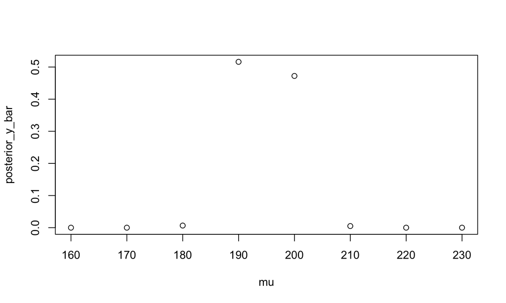

```r
plot(x = mu, y = posterior_y_bar)
```

## 11.2 Bayes’ Theorem for Normal Mean with a Continuous Prior

## To motivate these analyses let’s collect some data from the class

```r
sleep_times <- c(6.5, 6.5, 8, 6, 6, 6, 7, 7, 3, 7, 7, 8, 6, 9.25, 6, 7, 7, 7.5, 8, 6, 4)
mean(sleep_times)
```

```
## [1] 6.607143
```

```r
sd(sleep_times)
```

```
## [1] 1.352247
```

## Flat prior for \(\mu\) (Jeffrey’s Prior for Normal Mean)

Since \(g(\mu)=1\) everywhere on the real line the posterior \((\mu | y_1, \ldots, y_n) \sim Normal(\bar{y}, \sigma^2 / n)\).

## Normal prior

Let’s discuss the derivation of the updated (posterior) parameters for the normal mean \(\mu\) under a conjugate (normal-normal) model.

Equation 11.4:

\[ m^\prime = \frac{(\sigma^2 m + s^2 y)}{\sigma^2 + s^2} = \frac{\sigma^2}{\sigma^2 + s^2} \times m + \frac{s^2}{\sigma^2 + s^2} \times y \]

\[ (s^\prime)^2 = \frac{\sigma^2 s^2}{\sigma^2 + s^2} \]

Or in terms of precision \(1 / \sigma^2\):

By factoring out, we see that

\[ m^\prime = \frac{1 / s^2}{1 / \sigma^2 + 1 / s^2} \times m + \frac{1 / \sigma^2}{1 / \sigma^2 + 1 / s^2} \times y \]

\[ \frac{1}{(s^\prime)^2} = \left( \frac{\sigma^2 s^2}{\sigma^2 + s^2} \right)^{-1} = \frac{\sigma^2 + s^2}{\sigma^2 s^2} =\frac{1}{\sigma^2} + \frac{1}{s^2} \]

## From a random sample \(y_1, \ldots, y_n\)

\[ \frac{1}{(s^\prime)^2} = \frac{1}{s^2} + \frac{n}{\sigma^2} \]

\[ m^\prime = \frac{1 / s^2}{n / \sigma^2 + 1 / s^2} \times m + \frac{n / \sigma^2}{n / \sigma^2 + 1 / s^2} \times \bar{y} \]

## 11.3 Choosing Your Normal Prior

Choose your prior mean \(m\) and prior variance \(s^2\) based on your prior beliefs about \(E(\mu)\) and \(Var(\mu)\). Remember that means are less variable than individual observations.

It is recommended to check your *equivalent sample size*: Set your prior variance \(s^2 = \sigma^2 / n_{eq}\) and solve for \(n_{eq}\).

```r
## 6 to 8 hours
m <- 7
s2 <- 2
sqrt(s2)
```

```
## [1] 1.414214
```

```r
## assume true sigma (or could estimate from data)
sigma2 <- 2
## then equivalent sample size in the prior specification is
(n_eq <- sigma2/s2)
```

```
## [1] 1
```

```r
update_normnp <- function(m, s2, n, y_bar, sigma2){
    ## posterior precision is the sum of prior and sample precision
    total_precision <- 1/s2 + n/sigma2
    s_prime2 <- 1/total_precision
    ## posterior mean is the weighted average of prior and sample mean
    m_prime <- ( (1/s2) / total_precision ) * m + ( (n/sigma2) / total_precision ) * y_bar
    ## return as a list
    list(m_prime=m_prime, s_prime2=s_prime2, s_prime = sqrt(s_prime2))
}

y_bar <- mean(sleep_times)
n <- length(sleep_times)
sigma2 <- 2
s2 <- 2
m <- 7
update_normnp(m = m, s2 = s2, n = n, y_bar = y_bar, sigma2 = sigma2)
```

```
## $m_prime
## [1] 6.625
##
## $s_prime2
## [1] 0.09090909
##
## $s_prime
## [1] 0.3015113
```

```
## Known standard deviation :1.414
## Posterior mean           : 6.625
## Posterior std. deviation : 0.3015113
```

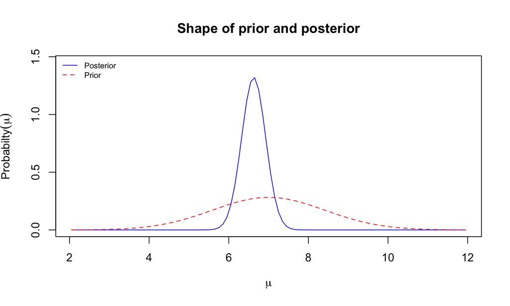

```
##
## Prob.    Quantile
## ------   ----------
## 0.005     5.8483582
## 0.010     5.9235797
## 0.025     6.0340486
## 0.050     6.1290580
## 0.500     6.6250000
## 0.950     7.1209420
## 0.975     7.2159514
## 0.990     7.3264203
## 0.995     7.4016418
```

```r
Bolstad::normnp(x = sleep_times, m.x = m, s.x = sqrt(s2), sigma.x = sqrt(sigma2), plot = TRUE)
```

## 11.4 Bayesian Credible Interval for Normal Mean

## Known variance

```r
posterior <- update_normnp(m = m, s2 = s2, n = n, y_bar = y_bar, sigma2 = sigma2)

## 89% credible Interval
alpha = 0.11
z_alpha_over_2 <- qnorm(p = 1 - alpha/2)

(lower <-  posterior$m_prime - z_alpha_over_2* posterior$s_prime)
```

```
## [1] 6.143127
```

```r
(upper  <-  posterior$m_prime + z_alpha_over_2* posterior$s_prime)
```

```
## [1] 7.106873
```

## Unknown variance

```r
## use the sample variance estimated for sigma2
sigma2 <- var(sleep_times)
posterior <- update_normnp(m = m, s2 = s2, n = n, y_bar = y_bar, sigma2 = sigma2)

## 89% credible Interval
alpha = 0.11
## additional uncertainty
t_alpha_over_2 <- qt(p = 1 - alpha/2, df = n - 1)

(lower <-  posterior$m_prime - t_alpha_over_2* posterior$s_prime)
```

```
## [1] 6.140413
```

```r
(upper  <-  posterior$m_prime + t_alpha_over_2* posterior$s_prime)
```

```
## [1] 7.106654
```

## 11.5 Predictive Density for Next Observation

- The predictive distribution of the next observation \(y_{n+1}\) is normal\((m^\prime, (s^\prime)^2)\) where the mean \(m^\prime = m_n\), the posterior mean, and, the observation variance plus the posterior variance. (The posterior variance allows for the uncertainty in estimating \(\mu\).) The predictive (posterior) distribution is found by marginalizing \(\mu\) out of the joint distribution \(f(y_{n+1}, \mu | y_1, \ldots, y_n)\).
- Let’s discuss the derivation of Equation 11.9. It is a beastly bit of algebra. Keep the goal in mind and be thankful you don’t have to do this since someone already did.

```r
## predictive distribution
compute_normnp_predictive <- function(m, s2, n, y_bar, sigma2){
    posterior_params <- update_normnp(m = m, s2 = s2, n = n, y_bar = y_bar, sigma2 = sigma2)
    ## return as a list
    list(m_nplus1 = posterior_params$m_prime, s_nplus1_2= sigma2 + posterior_params$s_prime2)
}
```

## compare posterior to predictive

```r
update_normnp(m = 7, s2 = 1, n = n, y_bar = y_bar, sigma2 = 1)
```

```
## $m_prime
## [1] 6.625
##
## $s_prime2
## [1] 0.04545455
##
## $s_prime
## [1] 0.2132007
```

```r
compute_normnp_predictive(m = m, s2 = 1, n = n, y_bar = y_bar, sigma2 = 1 )
```

```
## $m_nplus1
## [1] 6.625
##
## $s_nplus1_2
## [1] 1.045455
```

## Summary

## Main points

- Analyzing the observations sequentially one at a time, using the posterior from the previous observation as the next prior, gives the same results as analyzing all the observations at once using the initial prior.
- The likelihood of a random sample of normal observations is proportional to the likelihood of the sample mean.
- The conjugate family of priors for normal observations with known variance is the normal(m, s2) family.
- If we have a random sample of normal observations and use a normal(m, s2) prior the posterior is normal(m’, (s’)2), where m’ and (s’)2 are found by the simple updating rules:
1. The precision is the reciprocal of the variance.
2. Posterior precision is the sum of the prior precision and the precision of the sample.
3. The posterior mean is the weighted average of the prior mean and the sample mean, where the weights are the proportions of their precisions to the posterior precision.
- The same updating rules work for the flat prior, remembering the flat prior has precision equal to zero.
- A Bayesian credible interval for μ can be found using the posterior distribution.
- If the variance σ2 is not known, we use the estimate of the variance calculated from the sample, , and use the critical values from the Student’s t table where the degrees of freedom is n — 1, the sample size minus 1. Using the Student’s t critical values compensates for the extra uncertainty due to not knowing σ2. (This actually gives the correct credible interval if we used a prior and marginalized σ2 out of the joint posterior.)

## Closing

- State simply: How to conduct Bayesian Inference Normal mean?
- What is the difference between the *posterior* and the *predictive posterior*?